# Feature selection tutorial with medioambiental dataset

Diabb Zegpi

## Correlation

If you’re working with a model that asumes linear relationship, correlation is a good first step for makeing a list of candidate predictors. For this example, we’re going to use *CO2*, which contains the results of an experiment on the cold tolerance of grass. Grass samples from two regions (Quebec and Mississippi) were grown in either a chilled or nonchilled environment, and their $CO_2$ uptake rate was tested.

| Plant | Type | Treatment | conc | uptake |
| --- | --- | --- | --- | --- |
| Qn1 | Quebec | nonchilled | 95 | 16.0 |
| Qn1 | Quebec | nonchilled | 175 | 30.4 |
| Qn1 | Quebec | nonchilled | 250 | 34.8 |
| Qn1 | Quebec | nonchilled | 350 | 37.2 |
| Qn1 | Quebec | nonchilled | 500 | 35.3 |
| Qn1 | Quebec | nonchilled | 675 | 39.2 |

The analysis will be oriented in the `tidyverse` approach. Let’s start with some exploratory analysis.

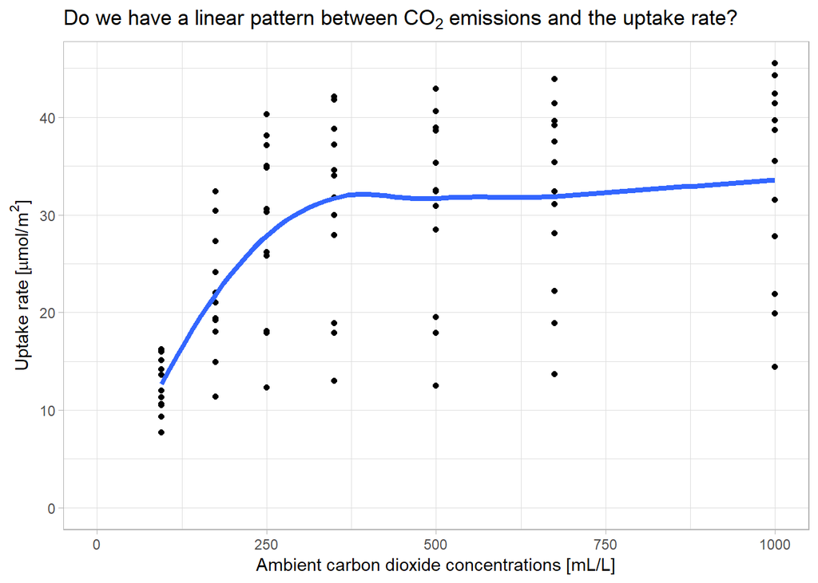

The first impression is that the uptake rate increases linearly until ambient carbon dioxide concentration reach 350 mL/L. Then, the slope of the curve approaches to zero. One interpretation is that grass plants get saturated at high levels of carbon dioxide concentration (*over 350*). In any case, the correlation exist and is **direct and moderate**.

```r
cor.test(co2$conc, co2$uptake) %>% tidy() %>%
  kable() %>%
  kable_styling(bootstrap_options = c("striped", "hover", "condensed", "responsive"), full_width = FALSE)
```

| estimate | statistic | p.value | parameter | conf.low | conf.high | method | alternative |
| --- | --- | --- | --- | --- | --- | --- | --- |
| 0.4851774 | 5.024461 | 2.9e-06 | 82 | 0.3022189 | 0.6336595 | Pearson’s product-moment correlation | two.sided |

Here, the analysis bifurcates into two approaches:

1. Treat the variable **as a factor**
2. Compare the ambient carbon dioxide concentrations between grass plants. Perhaps, the uptake rate relies on the location.

In both cases, we dig into the categorical variables.

## ANOVA

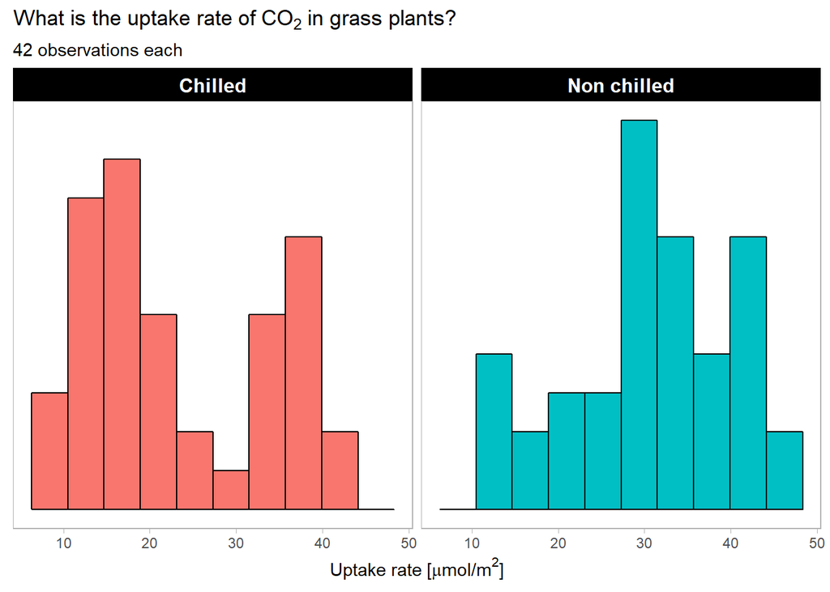

Apparently, non chilled plants tend to uptake more $CO_2$ than chilled plants. The question is if the difference is statistically significant or not. With that purpose, we will performance an *ANOVA* test to see if the *levels* of **Treatment** make a difference in de **uptake rate**.

To perform *ANOVA* correctly, we have to ensure that de levels of the cuantitative variable are normally distributed, We do that with the *Shapiro-Wilk test*.

```r
shapiro.test(filter(co2, Treatment == "nonchilled") %>% pull(uptake)) %>%
  tidy() %>%
  rbind(shapiro.test(filter(co2, Treatment == "chilled") %>% pull(uptake)) %>% tidy()) %>%
  kable() %>%
  kable_styling(bootstrap_options = c("striped", "hover", "condensed", "responsive"), full_width = FALSE)
```

| statistic | p.value | method |
| --- | --- | --- |
| 0.9450490 | 0.0430199 | Shapiro-Wilk normality test |
| 0.8978853 | 0.0012451 | Shapiro-Wilk normality test |

Now is time for *ANOVA test*.
$$H_0: \mu_A = \mu_B \\ H_1: \mu_A \neq \mu_B \\ A\ and\ B\ are\ levels\ of\ Treatment$$

```r
modelo_anova <- aov(uptake ~ Treatment, data = co2)
tidy(modelo_anova) %>%
  kable() %>%
  kable_styling(bootstrap_options = c("striped", "hover", "condensed", "responsive"), full_width = FALSE)
```

| term | df | sumsq | meansq | statistic | p.value |
| --- | --- | --- | --- | --- | --- |
| Treatment | 1 | 988.1144 | 988.1144 | 9.293115 | 0.0030957 |
| Residuals | 82 | 8718.8612 | 106.3276 | NA | NA |

According to the test, Treatment is meaningfull for explaining the variance of uptake, but is there a chilling effect making variate the uptake rate? The **Honest Significant Difference test** (or *Tukey’s test*) creates confidencenintervals following a studentized range distribution to compare the means of a factor’s levels and answer this question.

```r
TukeyHSD(modelo_anova, conf.level = 0.95) %>%
  tidy() %>%
  kable() %>%
  kable_styling(bootstrap_options = c("striped", "hover", "condensed", "responsive"), full_width = FALSE)
```

| term | comparison | estimate | conf.low | conf.high | adj.p.value |
| --- | --- | --- | --- | --- | --- |
| Treatment | chilled-nonchilled | -6.859524 | -11.33581 | -2.38324 | 0.0030957 |

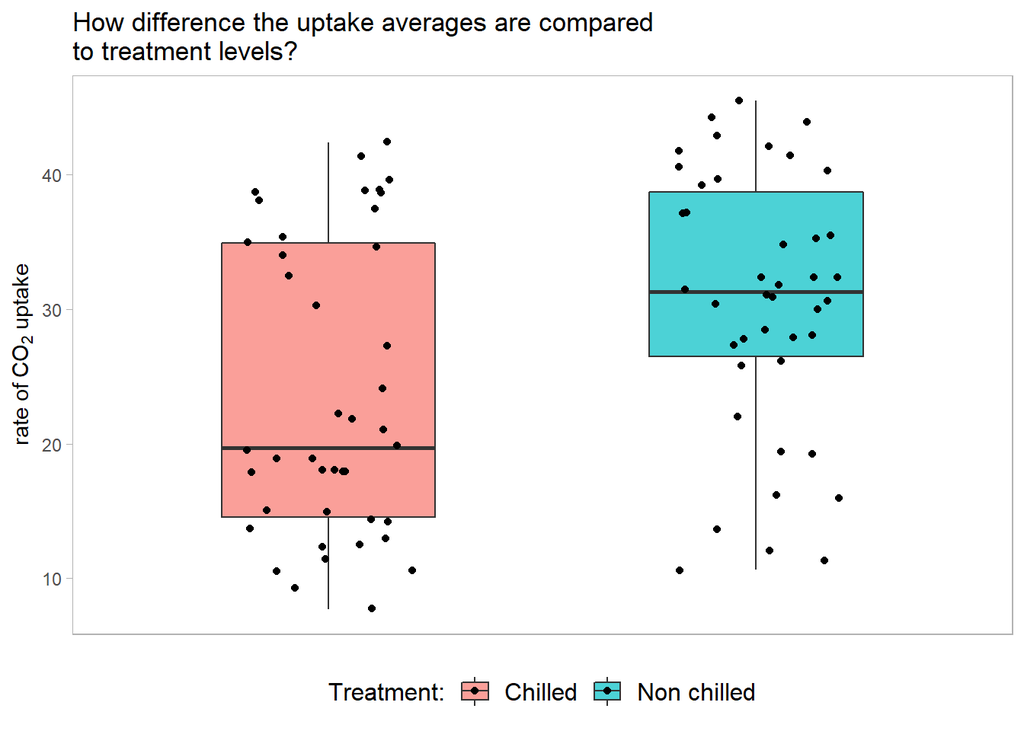

## Conclusion

- Treatment’s variance is significant to explain uptake’s.
- The **Tukey test** revealed that levels of treatment make a difference in the rate of $CO_2$ uptake on these grass plants.
- Using treatment as a feature to predict uptake is a correct decision.

## Chi-squared

In order to select the most important features for building a predictive model, we can apply the *chi-square test* to determine if the response is dependent on the given variables. Like all statistical tests, chi-squared test assumes a null hypothesis and an alternate hypothesis. The general practice is, if the p-value that comes out in the result is less than a pre-determined significance level, which is 0.05 usually, then we reject the null hypothesis.

$$H_0: the\ two\ variables\ are\ independent\\ H_1: the\ two\ variables\ are\ related$$

Chi-squared receives categorical data and make a comparisson between the actual and expected effect on the response variable. The question that attempts to ans is: are the variables related? Because the numerical nature of some variables, the `chi.squared` function of `FSelector` package discretizes all the continuous colums in the dataset.

```r
library(FSelector)
chi.squared(uptake ~ ., data = co2) %>% # cutoff.k(3) %>% as.simple.formula("uptake") to see top 3 variables in a formula
  mutate(feature = row.names(.)) %>%
  as_tibble() %>%
  arrange(desc(attr_importance)) %>%
  kable() %>%
  kable_styling(bootstrap_options = c("striped", "hover", "condensed", "responsive"), full_width = FALSE)
```

| attr_importance | feature |
| --- | --- |
| 0.6542970 | conc |
| 0.6537170 | Type |
| 0.5836084 | Plant |
| 0.4285422 | Treatment |

`chi.squared` shows weigths of discrete attributes basing on a chi-squared test. More information available in [FSelector Package Documentation](https://cran.r-project.org/web/packages/FSelector/FSelector.pdf).

You can also use `chisq.test` from `stats` to get more information out of the test, like de statistic, p-values and degrees of freedom, but you must discretize your data manually.

```r
co2 %>%
  mutate(uptake_discretized = arules::discretize(uptake, method = "cluster", labels = c("low", "medium", "high")),
         conc_discretized = arules::discretize(uptake, method = "cluster", labels = c("low", "medium", "high"))) %>%
  select(-conc, -uptake) %>%
  gather(feature, levels, -uptake_discretized) %>%
  group_by(feature) %>%
  nest() %>%
  mutate(chi_squared = map_dbl(data, ~ chisq.test(.x$uptake_discretized, .x$levels, correct = FALSE)$statistic),
         p_value = map_dbl(data, ~ chisq.test(.x$uptake_discretized, .x$levels, correct = FALSE)$p.value)) %>%
  select(-data) %>%
  kable() %>%
  kable_styling(bootstrap_options = c("striped", "hover", "condensed", "responsive"), full_width = FALSE)
```

| feature | chi_squared | p_value |
| --- | --- | --- |
| Plant | 71.130937 | 0.0000004 |
| Type | 26.148053 | 0.0000021 |
| Treatment | 6.196834 | 0.0451206 |
| conc_discretized | 72.093518 | 0.0000000 |